# Analyzing Individual BGG Users

Phil Henrickson

2022-01-01

# **Pyragor’s** BoardGameGeek Collection

This notebook contains a set of analyses for the selected user’s boardgamegeek collection. The bulk of the analysis is focused on building a user-specific predictive model to predict the games that Pyragor is likely to own. This enables to ask questions like, based on the games the user currently owns, what games are a good fit for their collection? What upcoming games are they likely to purchase?

This analysis is based on data from BoardGameGeek that was last updated on **2021-12-20.**

# 1 Collection Overview

We can look at a basic description of the number of games that the user owns, has rated, has previously owned, etc.

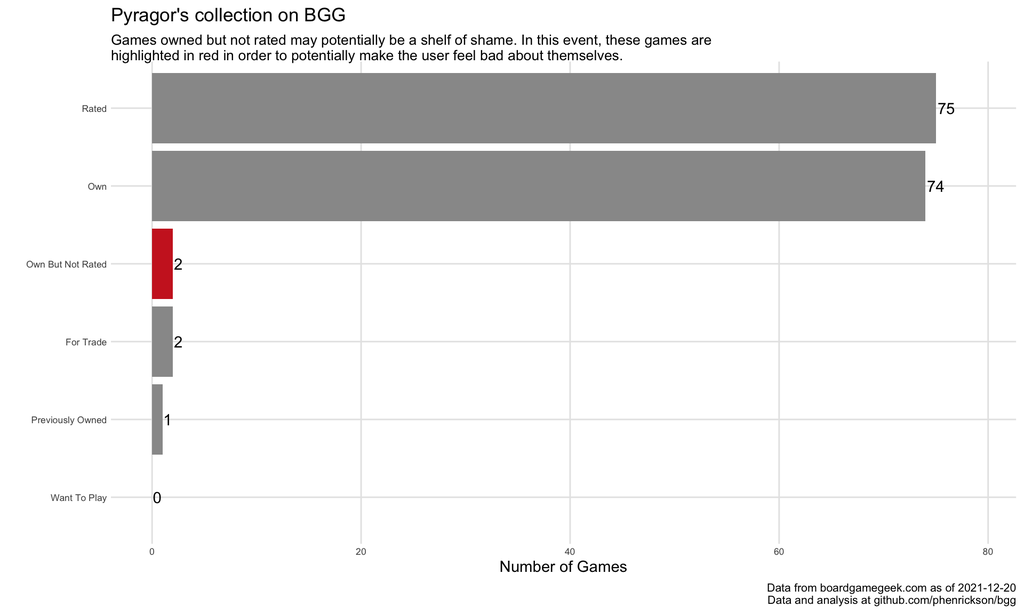

What years has the user owned/rated games from? While we can’t see when a user added or removed a game from their collection, we can look at their collection by the years in which their games were published.

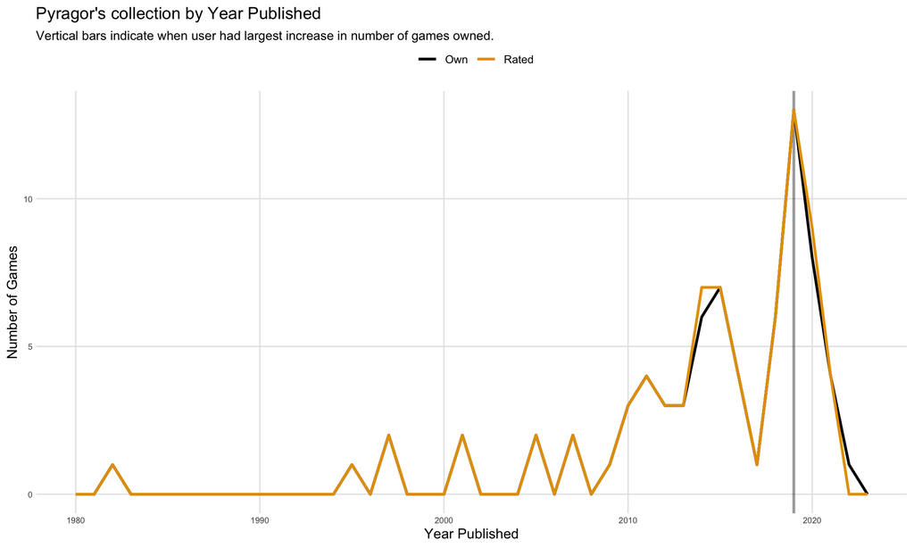

## 1.1 What types of games does Pyragor own?

We can look at the most frequent types of categories, mechanics, designers, and artists that appear in a user’s collection.

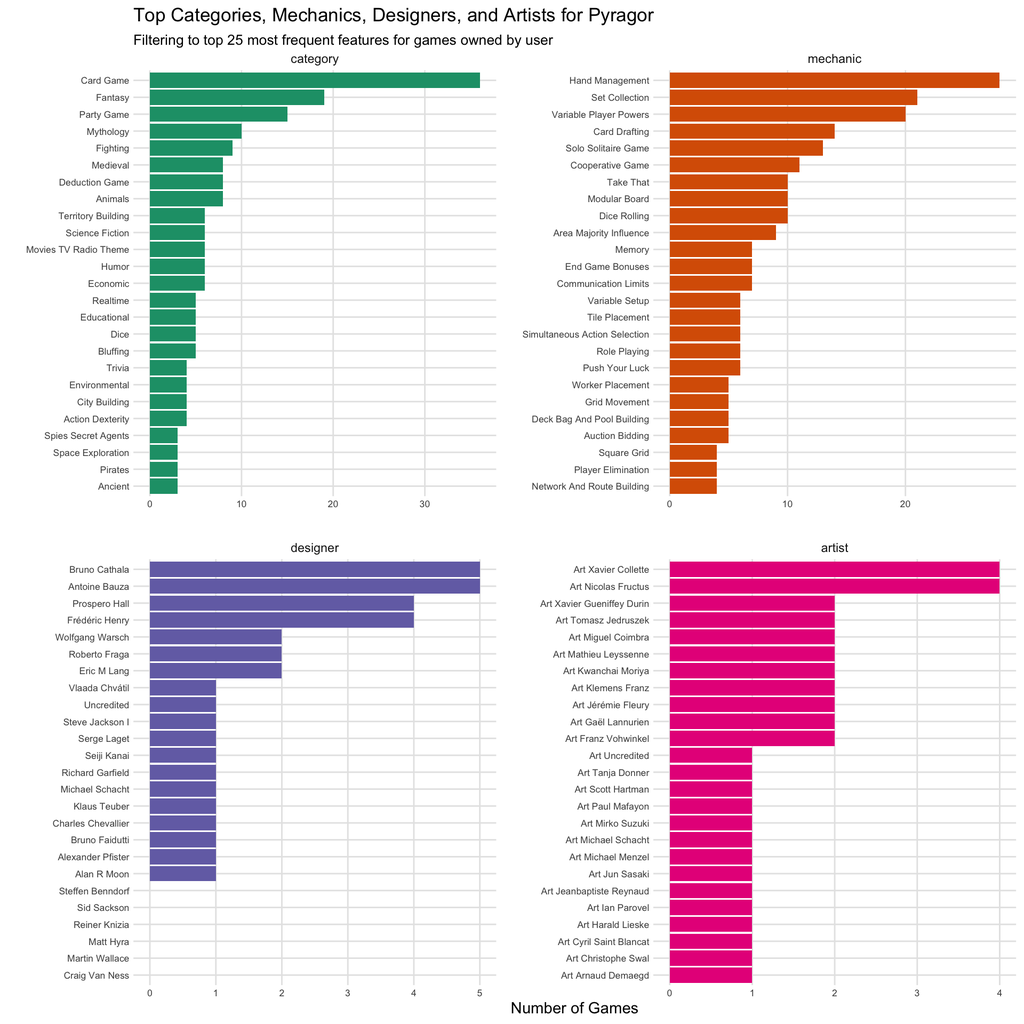

# 2 Modeling **Pyragor’s** Collection

| username | dataset | period | games_owned | games_rated | games_played |
| --- | --- | --- | --- | --- | --- |
| Pyragor | training | published before 2020 | 60 | 61 | 62 |
| Pyragor | test | published 2020 or later | 13 | 13 | 14 |

There are two main (binary) outcomes we will be modeling for the user.

The first, **own** refers to whether the user currently lists a game as owned in their collection. The second, **played** refers to whether the user currently owns, has rated, or previously owned a game. This means the latter will generally have a larger list of games, but may still be a useful category to examine for people who play lots of games without necessarily owning them.

We will train predictive models to learn the probability that the user will own or play individual games based on their features.

## 2.1 Coefficients for Pyragor

We can examine coefficients from the trained modes, which are penalized logistic regressions fit to our two main outcomes. Positive values indicate that a feature increases a user’s probabilility of owning/rating a game, while negative values indicate a feature decreases the probability.

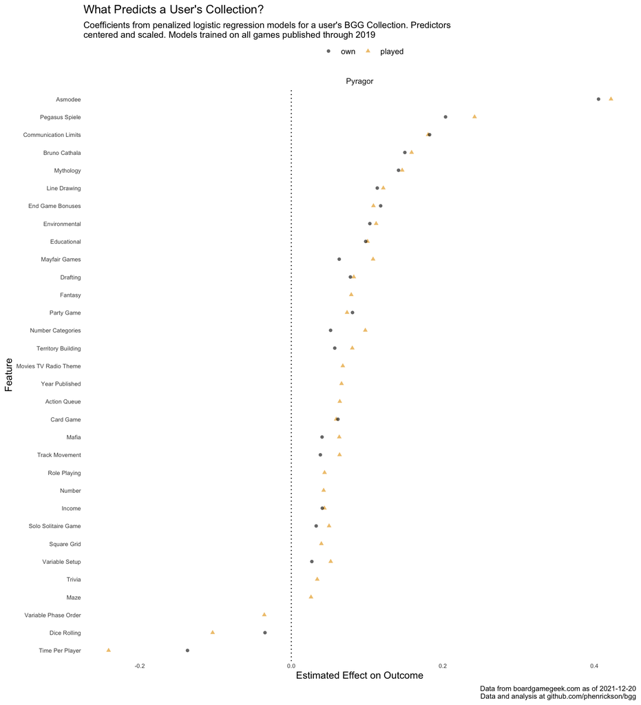

## 2.2 Visualizing Predictors for Pyragor’s Collection

Why did the model identify these features? We can make density plots of the important features for predicting whether the user owned a game. Blue indicates the density for games owned by the user, while grey indicates the density for games not owned by the user.

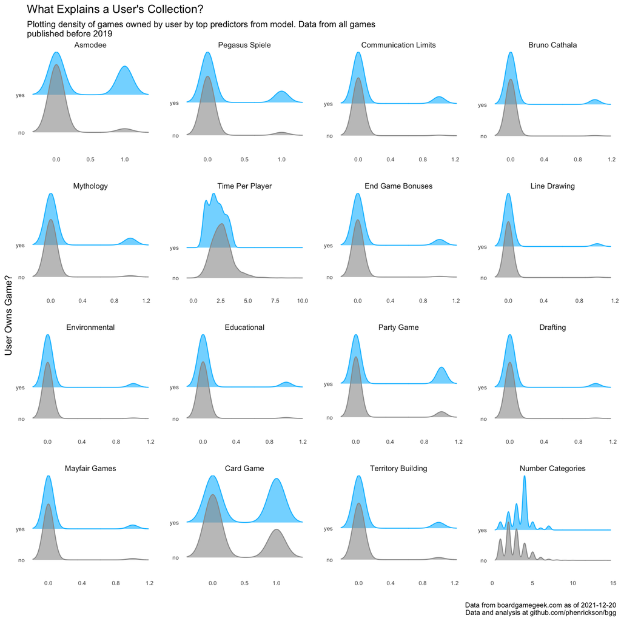

Binary predictors can be difficult to see with this visualization, so we can also directly examine the percentage of games in a user’s collection with a predictor vs the percentage of all games with that predictor.

| username | Feature | % of Games with Feature In_Collection | % of Games with Feature All_Games | Ratio |
| --- | --- | --- | --- | --- |
| Pyragor | Communication Limits | 11.7% | 0.9% | 12.7 |
| Pyragor | End Game Bonuses | 10.0% | 1.2% | 8.1 |
| Pyragor | Asmodee | 40.0% | 5.1% | 7.8 |
| Pyragor | Line Drawing | 5.0% | 0.7% | 7.1 |
| Pyragor | Income | 5.0% | 0.7% | 7.1 |
| Pyragor | Drafting | 6.7% | 1.0% | 6.6 |
| Pyragor | Environmental | 6.7% | 1.1% | 6.1 |
| Pyragor | Mythology | 11.7% | 2.2% | 5.3 |
| Pyragor | Educational | 8.3% | 1.6% | 5.3 |
| Pyragor | Track Movement | 3.3% | 0.7% | 5.1 |
| Pyragor | Mafia | 3.3% | 0.7% | 4.8 |
| Pyragor | Pegasus Spiele | 18.3% | 4.7% | 3.9 |
| Pyragor | Trivia | 6.7% | 1.8% | 3.7 |
| Pyragor | Number | 3.3% | 0.9% | 3.7 |
| Pyragor | Variable Setup | 6.7% | 1.9% | 3.6 |
| Pyragor | Square Grid | 5.0% | 1.4% | 3.5 |
| Pyragor | Party Game | 25.0% | 8.4% | 3.0 |
| Pyragor | Mayfair Games | 6.7% | 2.4% | 2.8 |
| Pyragor | Territory Building | 10.0% | 3.6% | 2.8 |
| Pyragor | Role Playing | 8.3% | 3.2% | 2.6 |
| Pyragor | Solo Solitaire Game | 13.3% | 5.9% | 2.3 |
| Pyragor | Movies TV Radio Theme | 8.3% | 3.9% | 2.1 |
| Pyragor | Fantasy | 25.0% | 14.8% | 1.7 |
| Pyragor | Card Game | 48.3% | 31.0% | 1.6 |
| Pyragor | Dice Rolling | 11.7% | 29.0% | 0.4 |

# 3 Assess Model’s Performance on Training Set

Before predicting games in upcoming years, we can examine how well the model did and what games it liked in the training set. In this case, we used resampling techniques (cross validation) to ensure that the model had not seen a game before making its predictions.

## 3.1 Separation Plot

An easy way to examine the performance of classification model is to view a separation plot. We plot the predicted probabilities from the model for every game (from resampling) from lowest to highest. We then overlay a blue line for any game that the user does own. A good classifier is one that is able to *separate* the blue (games owned by the user) from the white (games not owned by the user), with most of the blue occurring at the highest probabilities (right side of the chart).

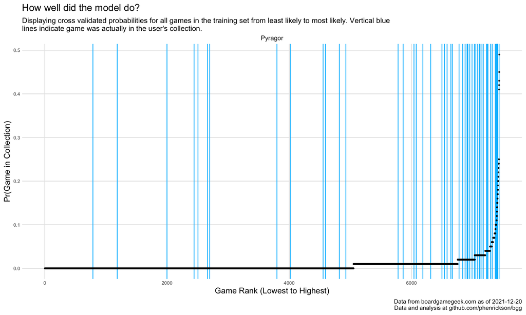

## 3.2 Top Games for **Pyragor** from Training Set

We can display this information in table form, displaying the 100 games with the highest probability of ownership, adding a blue line when the user does own the game.

| username | yearpublished | game_id | name | pred_played | pred_own | actual_played | actual_own |
| --- | --- | --- | --- | --- | --- | --- | --- |
| Pyragor | 2018 | 205896 | Rising Sun | 0.68 | 0.49 | 0 | 0 |
| Pyragor | 2016 | 167791 | Terraforming Mars | 0.27 | 0.45 | 0 | 0 |
| Pyragor | 2005 | 18258 | Mission: Red Planet | 0.25 | 0.43 | 0 | 0 |
| Pyragor | 2011 | 70919 | Takenoko | 0.29 | 0.42 | 1 | 1 |
| Pyragor | 2005 | 15062 | Shadows over Camelot | 0.28 | 0.41 | 0 | 0 |
| Pyragor | 2017 | 224037 | Codenames: Duet | 0.12 | 0.25 | 0 | 0 |
| Pyragor | 2018 | 225694 | Decrypto | 0.27 | 0.25 | 0 | 0 |
| Pyragor | 2013 | 145203 | Prosperity | 0.05 | 0.24 | 0 | 0 |
| Pyragor | 2019 | 270971 | Era: Medieval Age | 0.41 | 0.24 | 0 | 0 |
| Pyragor | 2014 | 153938 | Camel Up | 0.01 | 0.24 | 0 | 0 |
| Pyragor | 2016 | 198454 | When I Dream | 0.19 | 0.24 | 0 | 0 |
| Pyragor | 2018 | 258444 | Gingerbread House | 0.33 | 0.23 | 0 | 0 |
| Pyragor | 2009 | 54998 | Cyclades | 0.22 | 0.23 | 0 | 0 |
| Pyragor | 2017 | 218603 | Photosynthesis | 0.28 | 0.22 | 0 | 0 |
| Pyragor | 2007 | 33495 | Time's Up! Édition purple | 0.14 | 0.21 | 0 | 0 |
| Pyragor | 2012 | 116858 | Noah | 0.13 | 0.21 | 0 | 0 |
| Pyragor | 2014 | 163412 | Patchwork | 0.39 | 0.20 | 0 | 0 |
| Pyragor | 2019 | 263155 | One Key | 0.20 | 0.20 | 0 | 0 |
| Pyragor | 2005 | 22348 | Duplik | 0.20 | 0.20 | 0 | 0 |
| Pyragor | 2004 | 10997 | Boomtown | 0.13 | 0.20 | 0 | 0 |
| Pyragor | 2008 | 38713 | Time's Up! Edición Amarilla | 0.15 | 0.19 | 0 | 0 |
| Pyragor | 1999 | 1353 | Time's Up! | 0.13 | 0.18 | 0 | 0 |
| Pyragor | 2006 | 28025 | Wicked Witches Way | 0.20 | 0.18 | 0 | 0 |
| Pyragor | 2013 | 134453 | The Little Prince: Make Me a Planet | 0.16 | 0.18 | 0 | 0 |
| Pyragor | 2014 | 157354 | Five Tribes | 0.04 | 0.17 | 1 | 1 |
| Pyragor | 2015 | 178900 | Codenames | 0.20 | 0.17 | 1 | 1 |
| Pyragor | 2016 | 198773 | Codenames: Pictures | 0.27 | 0.17 | 0 | 0 |
| Pyragor | 2016 | 205158 | Codenames: Deep Undercover | 0.43 | 0.17 | 0 | 0 |
| Pyragor | 2013 | 147151 | Concept | 0.14 | 0.16 | 1 | 1 |
| Pyragor | 2010 | 88126 | Time's Up! Family | 0.16 | 0.16 | 0 | 0 |

[output cut: 70 more lines]

We can also more formally assess how well the model did in resampling by looking at the area under the receiver operating characteristic. A perfect model would receive a score of 1, while a model that cannot predict the outcome will default to a score of 0.5. The extent to which something is a *good* score depends on the setting, but generally anything in the .8 to .9 range is very good while the .7 to .8 range is perfectly acceptable.

| username | outcome_type | .metric | .estimator | .estimate |
| --- | --- | --- | --- | --- |
| Pyragor | own | roc_auc | binary | 0.803 |
| Pyragor | played | roc_auc | binary | 0.802 |

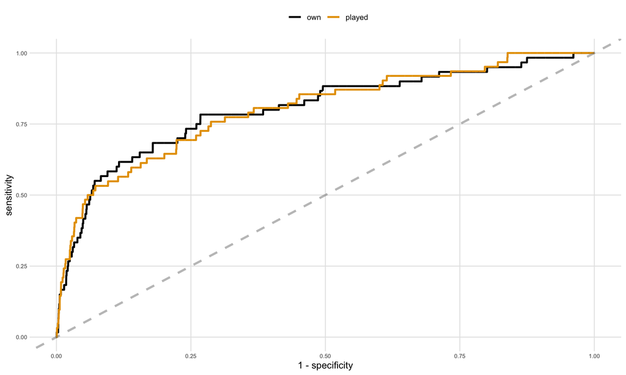

Another way to think about the model performance is to view its lift, or its ability to detect the positive outcomes over that of a null model. High lift indicates the model can much more quickly find all of the positive outcomes (in this case, games owned or played by the user), while a model with no lift is no better than random guessing.

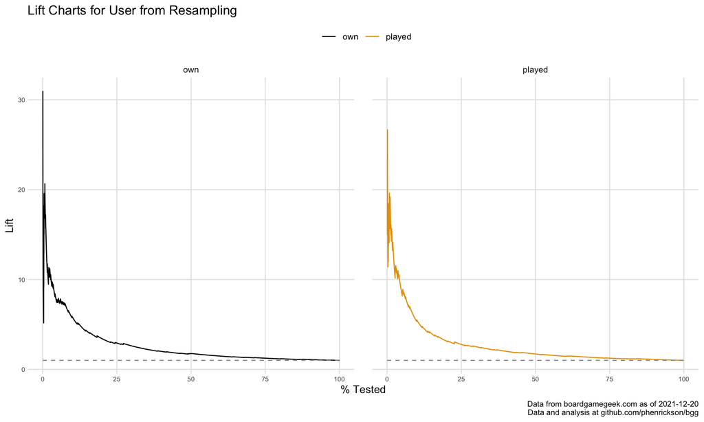

## 3.3 Most and Least Likely Games

What games does the model think Pyragor is **most likely to own** that are **not** in their collection?

| username | yearpublished | game_id | name | pred_own | actual_own |
| --- | --- | --- | --- | --- | --- |
| Pyragor | 2018 | 205896 | Rising Sun | 0.49 | 0 |
| Pyragor | 2016 | 167791 | Terraforming Mars | 0.45 | 0 |
| Pyragor | 2005 | 18258 | Mission: Red Planet | 0.43 | 0 |
| Pyragor | 2005 | 15062 | Shadows over Camelot | 0.41 | 0 |
| Pyragor | 2017 | 224037 | Codenames: Duet | 0.25 | 0 |

What games does the model think Pyragor is **least likely to own** that **are** in their collection?

| username | yearpublished | game_id | name | pred_own | actual_own |
| --- | --- | --- | --- | --- | --- |
| Pyragor | 2013 | 150298 | One Zero One | 0 | 1 |
| Pyragor | 2019 | 281259 | The Isle of Cats | 0 | 1 |
| Pyragor | 2018 | 244521 | The Quacks of Quedlinburg | 0 | 1 |
| Pyragor | 2012 | 126792 | Myrmes | 0 | 1 |
| Pyragor | 2016 | 209010 | Mechs vs. Minions | 0 | 1 |

## 3.4 Top Games by Year

Top 25 games most likely to be owned by the user in each year, highlighting in blue the games that the user has owned/played.

| rank | 2011 | 2012 | 2013 | 2014 | 2015 | 2016 | 2017 | 2018 | 2019 |
| --- | --- | --- | --- | --- | --- | --- | --- | --- | --- |
| 1 | Takenoko | Noah | Prosperity | Camel Up | Codenames | Terraforming Mars | Codenames: Duet | Rising Sun | Era: Medieval Age |
| 2 | Rory's Story Cubes: Voyages | Kemet | The Little Prince: Make Me a Planet | Patchwork | Blood Rage | When I Dream | Photosynthesis | Decrypto | One Key |
| 3 | Octopus's Garden | Timeline: General Interest | Concept | Five Tribes | Mysterium | Codenames: Pictures | Azul | Gingerbread House | The Magnificent |
| 4 | Timeline: Discoveries | Spot it! 1,2,3 | Timeline: Music & Cinema | Abyss | The Pursuit of Happiness | Codenames: Deep Undercover | Pandemic Legacy: Season 2 | Micropolis | Paranormal Detectives |
| 5 | Timeline: Events | Okiya | Cardline: Globetrotter | Witness | Elysium | Captain Sonar | Harvest Dice | Timeline: Classic | De Vulgari Eloquentia: Deluxe Edition |
| 6 | Streams | Shadows over Camelot: The Card Game | Room 25 | Timeline: Americana | Timeline: Star Wars | The Networks | Gloomhaven | Lords of Hellas | Ecosystem |
| 7 | Mage Knight Board Game | Love Letter | Cappuccino | Saboteur: The Duel | The Little Prince: Rising to the Stars | Braintopia | Queendomino | Sonar Family | Tiny Towns |
| 8 | Telestrations: 12 Player Party Pack | Timeline | Lewis & Clark: The Expedition | Deus | Timeline Challenge | Inis | Codenames: Disney – Family Edition | Heroes of Terrinoth | Yōkai |
| 9 | Mundus Novus | Cardline: Animals | Mascarade | Deception: Murder in Hong Kong | Salem 1692 | Hit Z Road | Fog of Love | Underwater Cities | On Tour |
| 10 | Skull | Seasons | BANG! The Dice Game | Pictopia: Disney Edition | Bang! The Dice Game: The Walking Dead | Timeline: British History | Pulsar 2849 | Century: Eastern Wonders | Amul |
| 11 | Sticky Stickz | Wits & Wagers Party | Dobble: Free Demo Version | HINT | Imagine | 13 Days: The Cuban Missile Crisis | Bunny Kingdom | Vengeance | Similo |
| 12 | Ascension: Storm of Souls | Dixit Jinx | Anomia: Party Edition | La Granja | Mafia de Cuba | Dream Home | The Shipwreck Arcana | Muse: Awakenings | Yggdrasil Chronicles |
| 13 | Tetris Link | The Cave | Crossing | Smash Up: Science Fiction Double Feature | Tiny Epic Galaxies | Smash Up: It's Your Fault! | Dice Forge | Trekking the National Parks: Second Edition | Yukon Airways |
| 14 | Dixit: Odyssey | Terra Mystica | Ladies & Gentlemen | Desperados of Dice Town | The Game | Agricola: Family Edition | Magic Maze | Fireball Island: The Curse of Vul-Kar | Century: A New World |
| 15 | Flash Point: Fire Rescue | PIX | Asgard's Chosen | Chosŏn | Haspelknecht | Kreus | Paper Tales | Azul: Stained Glass of Sintra | Maracaibo |
| 16 | Dr. Shark | Rumble in the Dungeon | Berserk: War of the Realms | Telestrations: 6 Player Family Pack | The King Is Dead | Kingdomino | Indian Summer | Sherlock: Death on the 4th of July | Last Bastion |
| 17 | Rumble in the House | Shrimp | Corto | Sheriff of Nottingham | Barony | Citadels | Spirit Island | Shadows: Amsterdam | Obscurio |
| 18 | Seven Dragons | Diavolo | Ascension: Rise of Vigil | Gaïa | Tales & Games: The Grasshopper & the Ant | Loot N Run | Muse | The World of SMOG: Rise of Moloch | Wingspan |
| 19 | A Few Acres of Snow | Coup | Rory's Story Cubes: Prehistoria | Smash Up: Monster Smash | Unusual Suspects | Histrio | Yamataï | Narabi | Sierra West |
| 20 | Omen: A Reign of War | Morels | Bomb Squad | Doodle Quest | Aye, Dark Overlord! The Green Box | Fight for Olympus | Gaia Project | Star Wars: Legion | Azul: Summer Pavilion |
| 21 | Ascension: Return of the Fallen | Divinare | Jungle Speed: Safari | Timeline: American History | The Grizzled | Roll Player | Sherlock Holmes Consulting Detective: Carlton House & Queen's Park | Codenames: Harry Potter | Barrage |
| 22 | The Blue Lion | The Big Bang Theory: The Party Game | Dungeon Twister: The Card Game | Ultimate Werewolf | Exploding Kittens: NSFW Deck | Covalence: A Molecule Building Game | Secrets | Everdell | Tainted Grail: The Fall of Avalon |
| 23 | Santiago de Cuba | Dixit: Journey | The Ravens of Thri Sahashri | Evolution | Tales & Games: Little Red Riding Hood | Mistfall: Heart of the Mists | This War of Mine: The Board Game | Blue Lagoon | Sherlock: Don's Legacy |
| 24 | The Secret of Monte Cristo | Space Cadets | Rivet Wars: Eastern Front | Hyperborea | Exploding Kittens | Dice Stars | Doodle Rush | Planet | ARTBOX |
| 25 | Letters from Whitechapel | A Fake Artist Goes to New York | Pizza Party | Artificium | Me Want Cookies! | Beyond Baker Street | The Godfather: Corleone's Empire | Forum Trajanum | Harry Potter: Hogwarts Battle – Defence Against the Dark Arts |

## 3.5 Interactive Predictions from Resampling

Interactive table for predictions from resampling.

|  | username | yearpublished | rank | game_id | name | pred_played | pred_own | actual_played | actual_own |
| --- | --- | --- | --- | --- | --- | --- | --- | --- | --- |
| 1 | Pyragor | 1900 | 196 | 45 | Perudo | 0.02 | 0.04 | 0 | 0 |
| 2 | Pyragor | 1900 | 326 | 15878 | Rummy | 0.13 | 0.03 | 0 | 0 |
| 3 | Pyragor | 1900 | 445 | 7316 | Bingo | 0.01 | 0.02 | 0 | 0 |
| 4 | Pyragor | 1900 | 721 | 1602 | The Royal Game of Ur | 0 | 0.01 | 0 | 0 |
| 5 | Pyragor | 1900 | 750 | 2932 | Hnefatafl | 0 | 0.01 | 0 | 0 |
| 6 | Pyragor | 1900 | 1005 | 2173 | 4 Player Chess | 0 | 0.01 | 0 | 0 |
| 7 | Pyragor | 1900 | 1103 | 21389 | Happy Families | 0.02 | 0.01 | 0 | 0 |
| 8 | Pyragor | 1900 | 1514 | 8689 | Bunco | 0 | 0.01 | 0 | 0 |
| 9 | Pyragor | 1900 | 1536 | 17003 | Snap | 0.01 | 0.01 | 0 | 0 |
| 10 | Pyragor | 1900 | 1591 | 15549 | Roulette | 0.01 | 0.01 | 0 | 0 |

[output cut: 7426 more lines]

# 4 Validating the Model on 2020

How well did a model trained on a user’s collection through 2019 perform in predicting games for the user from 2020?

| username | outcome_type | yearpublished | .metric | .estimator | .estimate |
| --- | --- | --- | --- | --- | --- |
| Pyragor | own | 2020 | roc_auc | binary | 0.649 |
| Pyragor | played | 2020 | roc_auc | binary | 0.671 |

Table of top 25 games from 2020, highlighting games that the user owns.

| username | yearpublished | game_id | name | pred_own | pred_played | actual_own | actual_played |
| --- | --- | --- | --- | --- | --- | --- | --- |
| Pyragor | 2020 | 301767 | Mysterium Park | 0.17 | 0.17 | 0 | 0 |
| Pyragor | 2020 | 291457 | Gloomhaven: Jaws of the Lion | 0.14 | 0.23 | 0 | 0 |
| Pyragor | 2020 | 297735 | Disciple Detective | 0.07 | 0.07 | 0 | 0 |
| Pyragor | 2020 | 302425 | Unlock!: Mythic Adventures | 0.07 | 0.08 | 0 | 0 |
| Pyragor | 2020 | 291874 | Dwergar | 0.06 | 0.05 | 0 | 0 |
| Pyragor | 2020 | 300010 | Dragomino | 0.06 | 0.08 | 0 | 0 |
| Pyragor | 2020 | 316377 | 7 Wonders (Second Edition) | 0.06 | 0.08 | 0 | 0 |
| Pyragor | 2020 | 184267 | On Mars | 0.05 | 0.05 | 0 | 0 |
| Pyragor | 2020 | 265784 | Cleopatra and the Society of Architects: Deluxe Edition | 0.05 | 0.05 | 0 | 0 |
| Pyragor | 2020 | 299592 | Beez | 0.05 | 0.06 | 0 | 0 |
| Pyragor | 2020 | 288513 | Tranquility | 0.04 | 0.05 | 0 | 0 |
| Pyragor | 2020 | 302734 | Master Word | 0.04 | 0.04 | 0 | 0 |
| Pyragor | 2020 | 307002 | Regicide | 0.04 | 0.05 | 0 | 0 |
| Pyragor | 2020 | 312786 | Poetry for Neanderthals | 0.04 | 0.04 | 0 | 0 |
| Pyragor | 2020 | 313531 | Blätterrauschen | 0.04 | 0.04 | 0 | 0 |
| Pyragor | 2020 | 323784 | Ghost Letters | 0.04 | 0.04 | 0 | 0 |
| Pyragor | 2020 | 245658 | Unicorn Fever | 0.03 | 0.04 | 0 | 0 |
| Pyragor | 2020 | 282171 | Trial by Trolley | 0.03 | 0.03 | 0 | 0 |
| Pyragor | 2020 | 288169 | The Fox in the Forest Duet | 0.03 | 0.03 | 0 | 0 |
| Pyragor | 2020 | 293014 | Nidavellir | 0.03 | 0.04 | 1 | 1 |
| Pyragor | 2020 | 294235 | Crime Zoom: His Last Card | 0.03 | 0.03 | 0 | 0 |
| Pyragor | 2020 | 296498 | 10 Dice | 0.03 | 0.02 | 0 | 0 |
| Pyragor | 2020 | 296517 | Contact: Signals from Outer Space | 0.03 | 0.03 | 0 | 0 |
| Pyragor | 2020 | 297030 | Tekhenu: Obelisk of the Sun | 0.03 | 0.04 | 0 | 0 |
| Pyragor | 2020 | 297204 | Traintopia | 0.03 | 0.03 | 0 | 0 |

# 5 Predicting Upcoming Games (2020 and On) for **Pyragor**

Examine the top games for the test set.

| username | yearpublished | game_id | name | rank | own | played |
| --- | --- | --- | --- | --- | --- | --- |
| Pyragor | 2020 | 301767 | Mysterium Park | 1 | 0.17 | 0.17 |
| Pyragor | 2020 | 291457 | Gloomhaven: Jaws of the Lion | 2 | 0.14 | 0.23 |
| Pyragor | 2020 | 297735 | Disciple Detective | 3 | 0.07 | 0.07 |
| Pyragor | 2020 | 302425 | Unlock!: Mythic Adventures | 4 | 0.07 | 0.08 |
| Pyragor | 2020 | 291874 | Dwergar | 5 | 0.06 | 0.05 |
| Pyragor | 2020 | 300010 | Dragomino | 6 | 0.06 | 0.08 |
| Pyragor | 2020 | 316377 | 7 Wonders (Second Edition) | 7 | 0.06 | 0.08 |
| Pyragor | 2020 | 265784 | Cleopatra and the Society of Architects: Deluxe Edition | 8 | 0.05 | 0.05 |
| Pyragor | 2020 | 184267 | On Mars | 9 | 0.05 | 0.05 |
| Pyragor | 2020 | 299592 | Beez | 10 | 0.05 | 0.06 |
| Pyragor | 2020 | 307002 | Regicide | 11 | 0.04 | 0.05 |
| Pyragor | 2020 | 302734 | Master Word | 12 | 0.04 | 0.04 |
| Pyragor | 2020 | 288513 | Tranquility | 13 | 0.04 | 0.05 |
| Pyragor | 2020 | 313531 | Blätterrauschen | 14 | 0.04 | 0.04 |
| Pyragor | 2020 | 323784 | Ghost Letters | 15 | 0.04 | 0.04 |
| Pyragor | 2020 | 312786 | Poetry for Neanderthals | 16 | 0.04 | 0.04 |
| Pyragor | 2020 | 332229 | Unlock!: Heroic Adventures – Hinunter in den Kaninchenbau | 17 | 0.03 | 0.02 |
| Pyragor | 2020 | 332230 | Unlock!: Heroic Adventures – Insert Coin | 18 | 0.03 | 0.02 |
| Pyragor | 2020 | 316554 | Dune: Imperium | 19 | 0.03 | 0.03 |
| Pyragor | 2020 | 294235 | Crime Zoom: His Last Card | 20 | 0.03 | 0.03 |
| Pyragor | 2020 | 321305 | Crime Zoom: A Bird of Ill Omen | 21 | 0.03 | 0.03 |
| Pyragor | 2020 | 317643 | Kyoto | 22 | 0.03 | 0.03 |
| Pyragor | 2020 | 293014 | Nidavellir | 23 | 0.03 | 0.04 |
| Pyragor | 2020 | 297204 | Traintopia | 24 | 0.03 | 0.03 |
| Pyragor | 2020 | 288169 | The Fox in the Forest Duet | 25 | 0.03 | 0.03 |
| Pyragor | 2021 | 326804 | Rorschach | 1 | 0.10 | 0.12 |
| Pyragor | 2021 | 298102 | Roll Camera!: The Filmmaking Board Game | 2 | 0.10 | 0.16 |
| Pyragor | 2021 | 315624 | World Changers | 3 | 0.07 | 0.08 |
| Pyragor | 2021 | 331635 | Kameloot | 4 | 0.07 | 0.09 |
| Pyragor | 2021 | 340041 | Kingdomino Origins | 5 | 0.06 | 0.07 |
| Pyragor | 2021 | 315767 | Cartographers Heroes | 6 | 0.06 | 0.11 |
| Pyragor | 2021 | 314491 | Meadow | 7 | 0.06 | 0.06 |
| Pyragor | 2021 | 332944 | Sobek: 2 Players | 8 | 0.06 | 0.07 |
| Pyragor | 2021 | 291859 | Riftforce | 9 | 0.06 | 0.09 |
| Pyragor | 2021 | 310873 | Carnegie | 10 | 0.05 | 0.04 |
| Pyragor | 2021 | 342942 | Ark Nova | 11 | 0.05 | 0.06 |
| Pyragor | 2021 | 285967 | Ankh: Gods of Egypt | 12 | 0.05 | 0.05 |
| Pyragor | 2021 | 298383 | Golem | 13 | 0.04 | 0.04 |
| Pyragor | 2021 | 343905 | Boonlake | 14 | 0.04 | 0.08 |
| Pyragor | 2021 | 323118 | Crack the Code | 15 | 0.03 | 0.02 |
| Pyragor | 2021 | 303676 | Oh My Brain | 16 | 0.03 | 0.03 |
| Pyragor | 2021 | 344415 | Trek 12: Amazonia | 17 | 0.03 | 0.03 |
| Pyragor | 2021 | 335541 | We Care: a Grizzled Game | 18 | 0.03 | 0.03 |
| Pyragor | 2021 | 324856 | The Crew: Mission Deep Sea | 19 | 0.03 | 0.03 |
| Pyragor | 2021 | 304666 | Wild Life: The Card Game | 20 | 0.03 | 0.03 |
| Pyragor | 2021 | 267333 | Goetia: Nine Kings of Solomon | 21 | 0.03 | 0.03 |
| Pyragor | 2021 | 290236 | Canvas | 22 | 0.03 | 0.03 |
| Pyragor | 2021 | 319999 | Dungeon Decorators | 23 | 0.03 | 0.05 |
| Pyragor | 2021 | 336552 | Mystic Paths | 24 | 0.03 | 0.04 |
| Pyragor | 2021 | 329839 | So Clover! | 25 | 0.03 | 0.03 |
| Pyragor | 2022 | 334065 | Verdant | 1 | 0.10 | 0.17 |
| Pyragor | 2022 | 317511 | Tindaya | 2 | 0.09 | 0.11 |
| Pyragor | 2022 | 304051 | Creature Comforts | 3 | 0.04 | 0.04 |
| Pyragor | 2022 | 295770 | Frosthaven | 4 | 0.03 | 0.03 |
| Pyragor | 2022 | 331106 | The Witcher: Old World | 5 | 0.03 | 0.06 |
| Pyragor | 2022 | 324090 | Scarface 1920 | 6 | 0.02 | 0.02 |
| Pyragor | 2022 | 348463 | ECO: Coral Reef | 7 | 0.02 | 0.03 |
| Pyragor | 2022 | 342444 | Black Rose Wars: Rebirth | 8 | 0.01 | 0.01 |
| Pyragor | 2022 | 256680 | Return to Dark Tower | 9 | 0.01 | 0.01 |
| Pyragor | 2022 | 294529 | Entropia: The Game | 10 | 0.01 | 0.01 |
| Pyragor | 2022 | 338067 | 6: Siege – The Board Game | 11 | 0.01 | 0.01 |
| Pyragor | 2022 | 322589 | Zapotec | 12 | 0.01 | 0.01 |
| Pyragor | 2022 | 322524 | Bardsung | 13 | 0.01 | 0.01 |
| Pyragor | 2022 | 258779 | Planet Unknown | 14 | 0.01 | 0.01 |
| Pyragor | 2022 | 271601 | Feed the Kraken | 15 | 0.01 | 0.01 |
| Pyragor | 2022 | 339592 | Sheep in Disguise | 16 | 0.01 | 0.01 |
| Pyragor | 2022 | 295895 | Distilled | 17 | 0.01 | 0.01 |
| Pyragor | 2022 | 240980 | Blood on the Clocktower | 18 | 0.01 | 0.01 |
| Pyragor | 2022 | 284189 | Foundations of Rome | 19 | 0.01 | 0.01 |
| Pyragor | 2022 | 332686 | John Company: Second Edition | 20 | 0.01 | 0.00 |
| Pyragor | 2022 | 321608 | Hegemony: Lead Your Class to Victory | 21 | 0.01 | 0.01 |
| Pyragor | 2022 | 330950 | Age of Galaxy | 22 | 0.01 | 0.01 |
| Pyragor | 2022 | 287871 | Hybris: Disordered Cosmos | 23 | 0.01 | 0.01 |
| Pyragor | 2022 | 344050 | Dubious | 24 | 0.01 | 0.01 |
| Pyragor | 2022 | 306311 | Eternal Palace | 25 | 0.01 | 0.01 |

## 5.1 Interactive Table for Upcoming Games 2020 and On

|  | username | yearpublished | game_id | name | rank | own | played |
| --- | --- | --- | --- | --- | --- | --- | --- |
| 1 | Pyragor | 2020 | 301767 | Mysterium Park | 1 | 0.17 | 0.17 |
| 2 | Pyragor | 2020 | 291457 | Gloomhaven: Jaws of the Lion | 2 | 0.14 | 0.23 |
| 3 | Pyragor | 2021 | 326804 | Rorschach | 3 | 0.1 | 0.12 |
| 4 | Pyragor | 2022 | 334065 | Verdant | 4 | 0.1 | 0.17 |
| 5 | Pyragor | 2021 | 298102 | Roll Camera!: The Filmmaking Board Game | 5 | 0.1 | 0.16 |
| 6 | Pyragor | 2022 | 317511 | Tindaya | 6 | 0.09 | 0.11 |
| 7 | Pyragor | 2020 | 297735 | Disciple Detective | 7 | 0.07 | 0.07 |
| 8 | Pyragor | 2020 | 302425 | Unlock!: Mythic Adventures | 8 | 0.07 | 0.08 |
| 9 | Pyragor | 2021 | 315624 | World Changers | 9 | 0.07 | 0.08 |
| 10 | Pyragor | 2021 | 331635 | Kameloot | 10 | 0.07 | 0.09 |

[output cut: 1627 more lines]